# Tugas_Bayes

russell

2024-11-17

```r
setwd("C:/Users/gerva/OneDrive/Documents/BINUS/SEM 3/BAYES/tugas")
data <- read.csv("homes_mapping_file.txt", header = TRUE, sep = "\t")
head(data)
```

```
##   ID        City State Latitude Longitude MeanAnnual.Temperature
## 1 12   Hopkinton    NH     43.2     -71.7               6.960092
## 2 13 Albuquerque    NM     35.1    -106.5              10.761468
## 3 14    Savannah    GA     32.1     -81.1              19.113914
## 4 15      Renton    WA     47.4    -122.1              11.172859
## 5 16  Fort Plain    NY     42.9     -74.7               6.766437
## 6 17       Ouray    CO     38.0    -107.7               3.639832
##   MeanAnnualPrecipitation NetPrimaryProductivity Elevation
## 1                87.59442              2.1444958  222.6697
## 2                26.16361              0.6215551 1708.6764
## 3               102.44121              2.4312538   11.9675
## 4                85.49419              2.1867050  144.7330
## 5                88.57339              2.1836766  429.1883
## 6                37.23991              0.9985993 2571.9460
##                                        Residence NumberBedroooms
## 1                                  A mobile home               3
## 2 One-family house detached from any other house               3
## 3 One-family house detached from any other house               2
## 4 One-family house detached from any other house               4
## 5 One-family house detached from any other house               3
## 6 One-family house detached from any other house               2
```

```r
str(data)
```

```
## 'data.frame':    1584 obs. of  11 variables:
##  $ ID                     : int  12 13 14 15 16 17 18 19 20 21 ...
##  $ City                   : chr  "Hopkinton" "Albuquerque" "Savannah" "Renton" ...
##  $ State                  : chr  "NH" "NM" "GA" "WA" ...
##  $ Latitude               : num  43.2 35.1 32.1 47.4 42.9 38 43.1 39.3 37.8 39.4 ...
##  $ Longitude              : num  -71.7 -106.5 -81.1 -122.1 -74.7 ...
##  $ MeanAnnual.Temperature : num  6.96 10.76 19.11 11.17 6.77 ...
##  $ MeanAnnualPrecipitation: num  87.6 26.2 102.4 85.5 88.6 ...
##  $ NetPrimaryProductivity : num  2.144 0.622 2.431 2.187 2.184 ...
##  $ Elevation              : num  223 1709 12 145 429 ...
##  $ Residence              : chr  "A mobile home" "One-family house detached from any other house" "One-family house detached from any other house" "One-family house detached from any other house" ...
##  $ NumberBedroooms        : chr  "3" "3" "2" "4" ...
```

NumberBedroooms is a char so we have to fix it

-check unique value of the column

```r
unique(data$NumberBedroooms)
```

```
## [1] "3"         "2"         "4"         "1"         "6 or more" "5"
```

- there is 6 or more

```r
data$NumberBedroooms[data$NumberBedroooms == '6 or more'] <- 6
unique(data$NumberBedroooms)
```

```
## [1] "3" "2" "4" "1" "6" "5"
```

- change datatype to int and log it

```r
data[,'NumberBedroooms'] <- as.numeric(data$NumberBedroooms)
data[,'NumberBedroooms'] <- log(data[,'NumberBedroooms'])
str(data)
```

```
## 'data.frame':    1584 obs. of  11 variables:
##  $ ID                     : int  12 13 14 15 16 17 18 19 20 21 ...
##  $ City                   : chr  "Hopkinton" "Albuquerque" "Savannah" "Renton" ...
##  $ State                  : chr  "NH" "NM" "GA" "WA" ...
##  $ Latitude               : num  43.2 35.1 32.1 47.4 42.9 38 43.1 39.3 37.8 39.4 ...
##  $ Longitude              : num  -71.7 -106.5 -81.1 -122.1 -74.7 ...
##  $ MeanAnnual.Temperature : num  6.96 10.76 19.11 11.17 6.77 ...
##  $ MeanAnnualPrecipitation: num  87.6 26.2 102.4 85.5 88.6 ...
##  $ NetPrimaryProductivity : num  2.144 0.622 2.431 2.187 2.184 ...
##  $ Elevation              : num  223 1709 12 145 429 ...
##  $ Residence              : chr  "A mobile home" "One-family house detached from any other house" "One-family house detached from any other house" "One-family house detached from any other house" ...
##  $ NumberBedroooms        : num  1.099 1.099 0.693 1.386 1.099 ...
```

- make a new dataframe that only includes the needed variables

```r
datanew <- data[, c(6,7,9,11)]
head(datanew)
```

```
##   MeanAnnual.Temperature MeanAnnualPrecipitation Elevation NumberBedroooms
## 1               6.960092                87.59442  222.6697       1.0986123
## 2              10.761468                26.16361 1708.6764       1.0986123
## 3              19.113914               102.44121   11.9675       0.6931472
## 4              11.172859                85.49419  144.7330       1.3862944
## 5               6.766437                88.57339  429.1883       1.0986123
## 6               3.639832                37.23991 2571.9460       0.6931472
```

- check missing val

```r
colSums(is.na(datanew))
```

```
##  MeanAnnual.Temperature MeanAnnualPrecipitation               Elevation
##                       0                       0                       0
##         NumberBedroooms
##                       0
```

x1 = temp x2 = precip x3 = elevation y = log bedroom

```r
set.seed(123)
#Rumus linear regressi
#y <- b0 + b1*x1 + b2*x2 + b3*x3 + error

# JAGS require all the data to be packaged as a list
library(rjags)
library(coda)

# Prepare data for JAGS
data_jags <- list(
  y = datanew$NumberBedroooms,
  x1 = datanew$MeanAnnual.Temperature,
  x2 = datanew$MeanAnnualPrecipitation,
  x3 = datanew$Elevation,
  n = nrow(datanew)
)

## 1. Define model as a string
model_string <- textConnection("model{
      #likelohood
      for(i in 1:n){
        y[i] ~ dnorm(b0 + b1*x1[i] + b2*x2[i] + b3*x3[i], tau)
      }

      #prior
      tau ~ dgamma(0.1, 0.1)
      sigma <- 1/sqrt(tau)
      b0 ~ dnorm(0,1000)
      b1 ~ dnorm(0,1000)
      b2 ~ dnorm(0,1000)
      b3 ~ dnorm(0,1000)
}")

## 2. Load the data and compile the MCMC code
inits <- list(b0=rnorm(1),b1=rnorm(1),b2=rnorm(1),b3=rnorm(1),tau=10)
model <- jags.model(model_string,data=data_jags,inits=inits, n.chains = 2, quiet = TRUE)

## 3. Burn-in for 10000 samples
update(model,10000,progress.bar = "none")

## 4. Generate 20000 post-burn-in samples and retain the parameters named in "params"
params <- c("b0","b1","b2","b3","sigma")
samples <- coda.samples(model, variable.names = params, n.iter = 20000, progress.bar="none")

## 5. Summarize the output
summary(samples)
```

```
##
## Iterations = 10001:30000
## Thinning interval = 1
## Number of chains = 2
## Sample size per chain = 20000
##
## 1. Empirical mean and standard deviation for each variable,
##    plus standard error of the mean:
##
##            Mean        SD  Naive SE Time-series SE
## b0    0.1691836 2.828e-02 1.414e-04      4.677e-04
## b1    0.0236546 2.443e-03 1.222e-05      4.685e-05
## b2    0.0046120 3.974e-04 1.987e-06      7.608e-06
## b3    0.0003403 2.572e-05 1.286e-07      2.174e-07
## sigma 0.4491646 8.111e-03 4.055e-05      4.656e-05
##
## 2. Quantiles for each variable:
##
##          2.5%       25%       50%       75%     97.5%
## b0    0.11293 0.1502246 0.1694045 0.1883993 0.2237857
## b1    0.01888 0.0220227 0.0236311 0.0252940 0.0284518
## b2    0.00384 0.0043431 0.0046091 0.0048767 0.0053997
## b3    0.00029 0.0003229 0.0003403 0.0003578 0.0003909
## sigma 0.43367 0.4436066 0.4490414 0.4545714 0.4653586
```

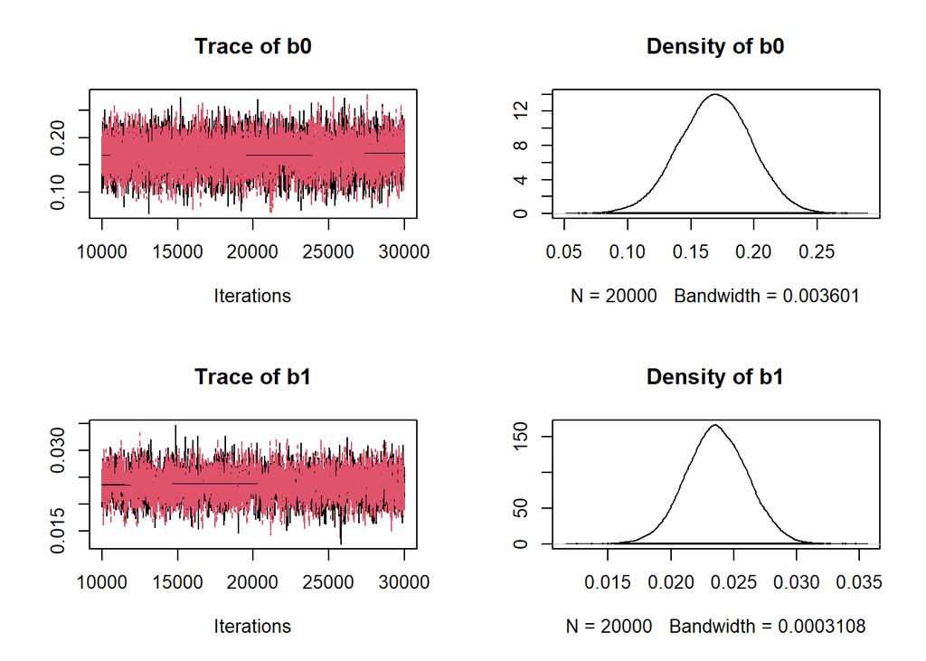

```r
# plot(samples)

# if the figure margin is too large then use this code
plot(samples[, c("b0", "b1")])
```

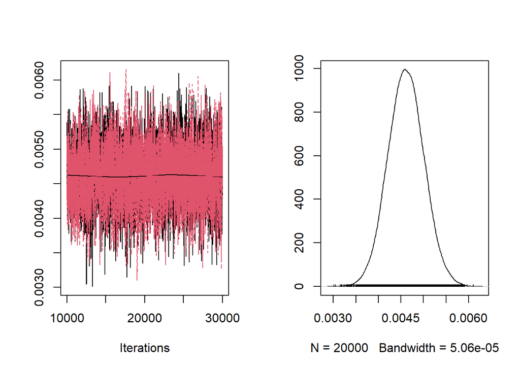

```r
plot(samples[, c("b2")])
```

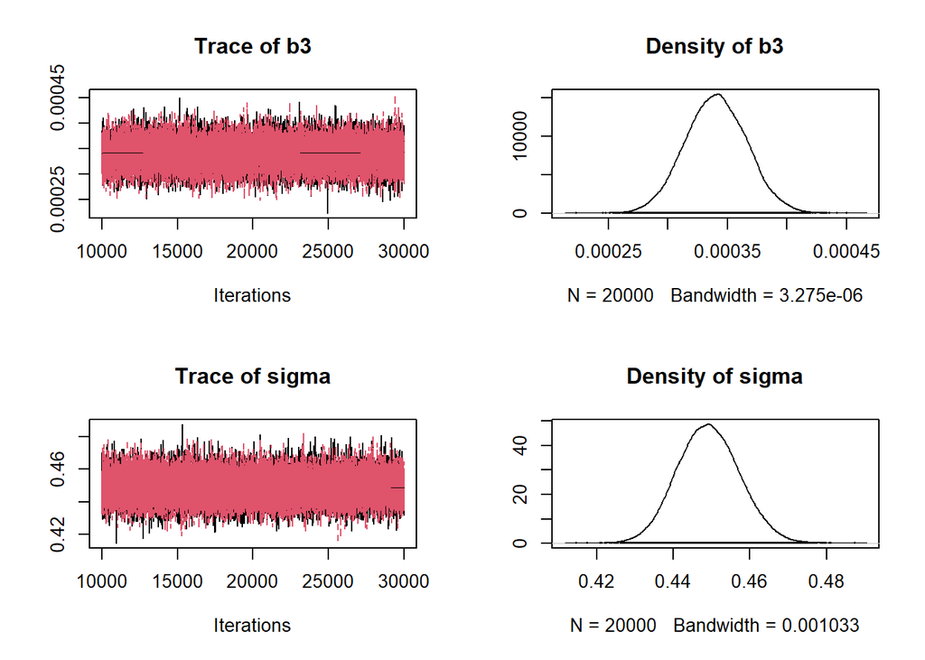

```r
plot(samples[, c("b3","sigma")])
```

INTERPRETATION - all the plot are stable and well mix - all are convergent meaning MCMC is sucessfull and explored the posterior dist effectively

-b1 density is around small positive value meaning weak posisitve relationship between temp and log nbedroom (higher temp slightly increase n bedroom) - b2 also small positive val also weak positive realtionship (higher precipitation only slightly increase lognbedroom) -b3 is also small positive but very close to zero (not so meaningful effect to log n bedroom) - sigma the plot si narrow indicating high certainty about the error term in the model

```r
set.seed(123)
#Rumus linear regressi
#y <- b0 + b1*x1 + b2*x2 + b3*x3 + error

# JAGS require all the data to be packaged as a list
library(rjags)

# Prepare data for JAGS
data_jags <- list(
  y = datanew$NumberBedroooms,
  x1 = datanew$MeanAnnual.Temperature,
  x2 = datanew$MeanAnnualPrecipitation,
  x3 = datanew$Elevation,
  n = nrow(datanew)
)

## 1. Define model as a string
model_string <- textConnection("model{
      #likelohood
      for(i in 1:n){
        y[i] ~ dnorm(b0 + b1*x1[i] + b2*x2[i] + b3*x3[i], tau)
      }

      taub1 ~ dgamma(0.1, 0.1)
      taub2 ~ dgamma(0.1, 0.1)
      taub3 ~ dgamma(0.1, 0.1)

      #prior
      tau ~ dgamma(0.1, 0.1)
      sigma <- 1/sqrt(tau)

      b0 ~ dnorm(0,1000)
      b1 ~ dnorm(0,1/taub1)
      b2 ~ dnorm(0,1/taub2)
      b3 ~ dnorm(0,1/taub3)
}")

## 2. Load the data and compile the MCMC code
inits <- list(b0=rnorm(1),b1=rnorm(1),b2=rnorm(1),b3=rnorm(1),tau=10)

model <- jags.model(model_string,data=data_jags,inits=inits, n.chains = 2, quiet = TRUE)

## 3. Burn-in for 10000 samples
update(model,10000,progress.bar = "none")

## 4. Generate 20000 post-burn-in samples and retain the parameters named in "params"
params <- c("b0","b1","b2","b3","sigma")
samples <- coda.samples(model, variable.names = params,n.iter = 20000,progress.bar="none")

## 5. Summarize the output
summary(samples)
```

```
##
## Iterations = 11001:31000
## Thinning interval = 1
## Number of chains = 2
## Sample size per chain = 20000
##
## 1. Empirical mean and standard deviation for each variable,
##    plus standard error of the mean:
##
##            Mean        SD  Naive SE Time-series SE
## b0    0.1704804 0.0285977 1.430e-04      4.571e-04
## b1    0.0237846 0.0024894 1.245e-05      4.595e-05
## b2    0.0045790 0.0004044 2.022e-06      7.653e-06
## b3    0.0003386 0.0000259 1.295e-07      2.277e-07
## sigma 0.4491303 0.0080332 4.017e-05      4.594e-05
##
## 2. Quantiles for each variable:
##
##            2.5%      25%       50%       75%     97.5%
## b0    0.1137128 0.151186 0.1705860 0.1898995 0.2261090
## b1    0.0188768 0.022119 0.0237810 0.0254517 0.0286486
## b2    0.0037845 0.004308 0.0045777 0.0048518 0.0053728
## b3    0.0002882 0.000321 0.0003387 0.0003561 0.0003898
## sigma 0.4338987 0.443647 0.4489813 0.4544951 0.4653037
```

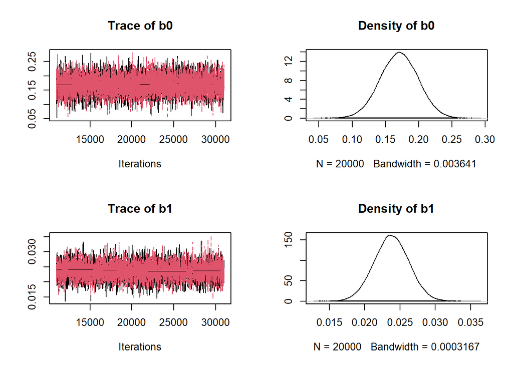

```r
# plot(samples)
plot(samples[, c("b0", "b1")])
```

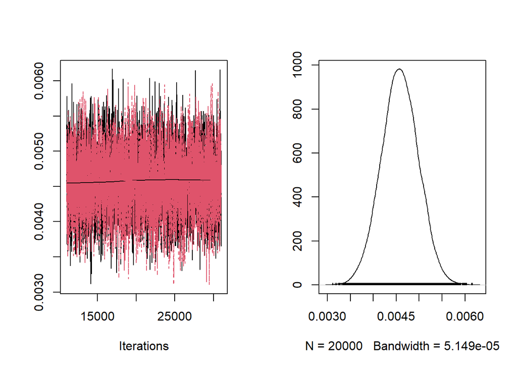

```r
plot(samples[, c("b2")])
```

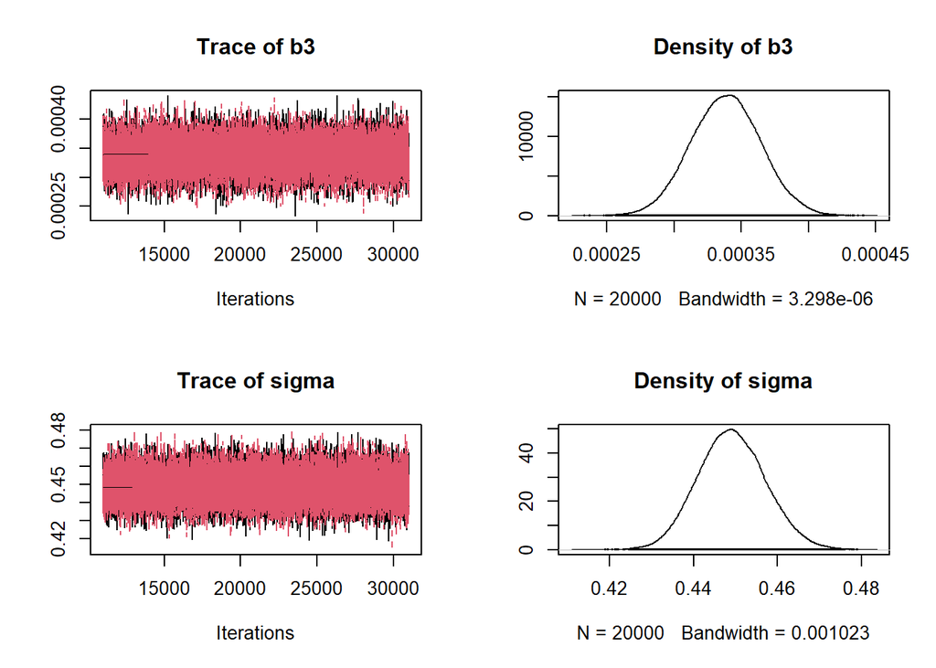

```r
plot(samples[, c("b3","sigma")])
```